# The Geysers: the well data

The project notebook uses one record of the industrial forcing: CalGEM's **field totals**, the steam produced and the water injected by the whole field, month by month. A field total says *how much* and *when*. It does not say *where*. The Geysers is about 15 km long, and its seismicity is not uniform along it, so the question "does injection cause these earthquakes?" is sharper when it can be asked well by well.

This notebook explores two per-well records from the California Geologic Energy Management Division (CalGEM). Youkang Zeng collected them in November 2026.

| File | What one row is | Source |
| --- | --- | --- |
| `geysers_wells.csv` | one well: its location, type, status, operator and dates | CalGEM *Geothermal Wells* layer |
| `geysers_well_injection_monthly.csv.gz` | one injection well in one month: the mass injected, and the rate, temperature and pressure reported with it | CalGEM GeoSteam *Well Injection Reports* |

The two files share the column `api`, the well's API number (a county code and a well code).

**Questions for this notebook**

1. Which wells exist at The Geysers, and which of them inject water?
2. What does one monthly injection report contain, and how much can we trust each column?
3. Do the per-well reports add up to the field totals we already use?
4. Where in the field does the water go, and how has that changed?
5. Does seismicity near a large injection well follow its injection?

The notebook is exploratory. It looks at the data and asks what they can support. It does not fit a model.

## § 0 · Setup

The cell below installs any missing package and imports the course's three helper modules. On DataHub the modules are already beside this notebook; on Colab they are downloaded. `asset(name)` downloads one file from the course data release once and returns its local path.

```python
import importlib.util
import subprocess
import sys
import urllib.request

REQUIRED = ["numpy", "pandas", "matplotlib", "scipy", "requests"]
missing = [pkg for pkg in REQUIRED if importlib.util.find_spec(pkg) is None]
if missing:
    subprocess.run([sys.executable, "-m", "pip", "install", "-q", *missing], check=True)

BASE = ("https://raw.githubusercontent.com/AI4EPS/"
        "EPS207_Observational_Seismology/main/docs/notebooks")
if "google.colab" in sys.modules or importlib.util.find_spec("geysers_data") is None:
    for module in ("geysers_data.py", "geysers_func.py", "geysers_plot.py"):
        urllib.request.urlretrieve(f"{BASE}/{module}", module)
    for name in ("geysers_data", "geysers_func", "geysers_plot"):
        sys.modules.pop(name, None)

from geysers_data import *    # noqa: F401,F403  -- the datasets
from geysers_func import *    # noqa: F401,F403  -- the calculations
from geysers_plot import *    # noqa: F401,F403  -- the figures

import numpy as np
import pandas as pd
import matplotlib.pyplot as plt

print(f"field window {FIELD}")
```

```
field window [-122.99, -122.65, 38.7, 38.899]
```

## § 1 · The wells

### 1.1 · Reading the well list

Every geothermal well that CalGEM has a record of in the course's download box is one row. We read the API number as text, because its leading zero is part of the code.

```python
wells = pd.read_csv(asset("geysers_wells.csv"), dtype={"api": str})
in_field = wells.longitude.between(*FIELD[:2]) & wells.latitude.between(*FIELD[2:])
print(f"{len(wells)} wells in the download box, {in_field.sum()} of them in the field window")
wells[in_field].head(3).T
```

```
1520 wells in the download box, 1080 of them in the field window
```

|  | 3 | 4 | 5 |
| --- | --- | --- | --- |
| api | 03390001 | 03390002 | 03390003 |
| name | McKinley 1 | McKinley 2 | McKinley 3 |
| lease | McKinley | McKinley | McKinley |
| well_number | 1 | 2 | 3 |
| latitude | 38.774835 | 38.773509 | 38.771903 |
| longitude | -122.719558 | -122.718712 | -122.718378 |
| county | Lake | Lake | Lake |
| field | GEYSR | GEYSR | GEYSR |
| well_type | Injection Well | Developmental Steam | Developmental Steam |
| status | Active | Plugged | Active |
| operator | Geysers Power Company, LLC | Santa Rosa Geothermal Co. | Geysers Power Company, LLC |
| spud_date | NaN | NaN | NaN |
| completion_date | NaN | NaN | NaN |
| abandon_date | NaN | NaN | NaN |
| directional | NaN | NaN | NaN |
| gis_source | NaN | HUD | NaN |

### 1.2 · What kinds of wells?

The Geysers is a **vapour-dominated** reservoir: production wells bring up dry steam, which drives the turbines. The steam is condensed, and part of the condensate, together with treated wastewater piped in from nearby towns, is sent back down **injection wells** to recharge the reservoir. Many shallow holes were also drilled only to measure how fast temperature rises with depth, during exploration.

```python
tab = pd.crosstab(wells[in_field].well_type, wells[in_field].status, margins=True, margins_name="all")
tab.sort_values("all", ascending=False)
```

| status well_type | Active | Cancelled | Conductor | Idle | Plugged | Proposed | Suspended | all |
| --- | --- | --- | --- | --- | --- | --- | --- | --- |
| all | 509 | 9 | 2 | 84 | 467 | 3 | 6 | 1080 |
| Developmental Steam | 411 | 7 | 1 | 41 | 146 | 0 | 5 | 611 |
| Temperature Gradient | 4 | 0 | 0 | 0 | 274 | 0 | 0 | 278 |
| Injection Well | 93 | 2 | 0 | 39 | 29 | 3 | 1 | 167 |
| Exploratory Steam | 0 | 0 | 0 | 4 | 18 | 0 | 0 | 22 |
| Conductor | 0 | 0 | 1 | 0 | 0 | 0 | 0 | 1 |
| Water Well | 1 | 0 | 0 | 0 | 0 | 0 | 0 | 1 |

Three kinds dominate: steam (production) wells, temperature-gradient holes, and injection wells. Only the injection wells have injection reports. Of these, the reports cover most but not all:

```python
inj = pd.read_csv(asset("geysers_well_injection_monthly.csv.gz"), dtype={"api": str})
injectors = wells[in_field & (wells.well_type == "Injection Well")]
reporting = injectors.api.isin(inj.api)
print(f"{len(injectors)} injection wells in the field window; "
      f"{reporting.sum()} have injection reports, {(~reporting).sum()} do not")
print("status of those without reports:", injectors[~reporting].status.value_counts().to_dict())
```

```
167 injection wells in the field window; 138 have injection reports, 29 do not
status of those without reports: {'Active': 19, 'Idle': 3, 'Proposed': 3, 'Cancelled': 2, 'Plugged': 2}
```

### 1.3 · Where the wells are

The map puts the wells over the earthquakes of 2012–2026 (M ≥ 1.5). Grey dots are steam wells, blue triangles injection wells with reports.

One caution before reading the map. **The coordinates are the wellhead, where the well leaves the surface.** Most wells at The Geysers are drilled at an angle, so the bottom of the hole, where the water actually enters the rock, can lie a kilometre or more away, at 1–3 km depth. The well list does not give the bottom-hole position. A map of wellheads is therefore a blurred map of where injection happens.

```python
ZOOM = [-122.93, -122.68, 38.73, 38.87]        # the part of the field window with wells
cat = catalog()
eq = cat[(cat.year >= 2012) & (cat.mag >= 1.5)
         & cat.longitude.between(*ZOOM[:2]) & cat.latitude.between(*ZOOM[2:])]
L = layers()

fig, ax = plt.subplots(figsize=(9, 6))
basemap(ax, L, ZOOM)
ax.scatter(eq.longitude, eq.latitude, s=2, color="#e07b4f", alpha=0.35, lw=0, zorder=3,
           label=f"earthquakes 2012–2026, M ≥ 1.5 ({len(eq):,})")
steam = wells[in_field & wells.well_type.str.contains("Steam")]
ax.scatter(steam.longitude, steam.latitude, s=6, color="0.35", lw=0, zorder=4,
           label=f"steam wells ({len(steam)})")
ax.scatter(injectors[reporting].longitude, injectors[reporting].latitude, s=28, marker="^",
           color="#1f5fa8", edgecolor="white", lw=0.4, zorder=5,
           label=f"injection wells with reports ({reporting.sum()})")
frame(ax, ZOOM, xtick=0.05, ytick=0.05, scale_km=5, scale_loc=(.75, .06))
ax.legend(loc="lower left", fontsize=8, framealpha=0.9, markerscale=2)
ax.set_title("The Geysers: wells over seismicity")
plt.show()
```

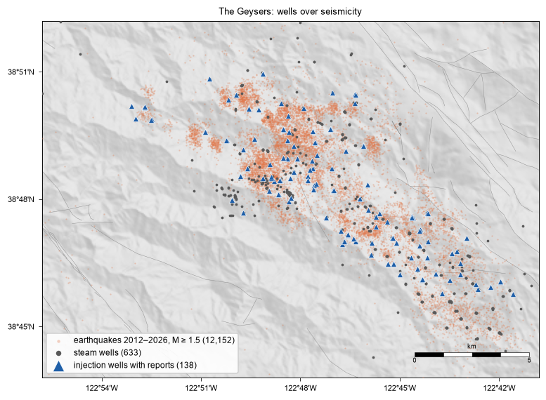

The wells and the earthquakes occupy the same NW–SE band. That is expected whatever the physics: wells are drilled where the steam is, and the earthquakes occur in the reservoir the wells drain and recharge. Overlap on a map is therefore not evidence that one causes the other. For that we need time as well as space (§ 5).

## § 2 · The monthly injection reports

### 2.1 · The columns

Each operator reports, for each injection well and each month:

| Column | Meaning | Unit |
| --- | --- | --- |
| `days` | days the well injected that month | day |
| `status` | `INJN` injecting, `SHTN` shut in, `IDLE`, ... | code |
| `well_type`, `condition` | CalGEM's well-type and condition codes, as reported | code |
| `injected_t` | gross mass of water injected | tonne (1,000 kg) |
| `rate_t_per_hr` | injection rate | tonne per hour |
| `temperature_c` | temperature of the injected water | °C |
| `pressure_bar` | wellhead pressure | bar |
| `tds_1000ppm`, `density_1000kg_m3` | dissolved solids and density of the water | as named |

A tonne of water is about one cubic metre, so `injected_t` is also, closely, a volume in m³.

```python
print(f"{len(inj):,} well-months from {inj.api.nunique()} wells, "
      f"{inj.year.min()}-{inj.year.max()} (last month {inj.query('year == year.max()').month.max()})")
inj.head()
```

```
31,205 well-months from 140 wells, 1969-2026 (last month 8)
```

|  | api | month | year | days | status | well_type | condition | injected_t | tds_1000ppm | density_1000kg_m3 | rate_t_per_hr | temperature_c | pressure_bar |
| --- | --- | --- | --- | --- | --- | --- | --- | --- | --- | --- | --- | --- | --- |
| 0 | 03390001 | 2 | 1997 | 16.0 | CONV | CI | S | 12720 | 0.1 | 1.0 | 24.2 | 25.0 | 0.0 |
| 1 | 03390001 | 3 | 1997 | 31.0 | SHTN | CI | S | 36046 | 0.1 | 1.0 | 34.7 | 30.2 | 0.0 |
| 2 | 03390001 | 4 | 1997 | 30.0 | SHTN | CI | S | 33840 | 0.1 | 1.0 | 43.8 | 28.2 | 0.0 |
| 3 | 03390001 | 5 | 1997 | 31.0 | SHTN | CI | S | 29467 | 0.1 | 1.0 | 46.4 | 30.6 | 0.0 |
| 4 | 03390001 | 6 | 1997 | 30.0 | SHTN | CI | S | 4908 | 0.1 | 1.0 | 33.4 | 38.1 | 0.0 |

### 2.2 · One well's history

We start with the well that has injected the most water over its life.

```python
inj["date"] = pd.to_datetime(dict(year=inj.year, month=inj.month, day=1))
life = inj.groupby("api").injected_t.sum().sort_values(ascending=False)
top = life.index[0]
w = wells.set_index("api").loc[top]
print(f"{top}  {w['name']}  ({w.latitude:.4f} N, {w.longitude:.4f} E), operator {w.operator}")
print(f"lifetime injection {life.iloc[0] / 1e6:.1f} million tonnes")

one = inj[inj.api == top].set_index("date").sort_index()
fig, axs = plt.subplots(3, 1, figsize=(10, 6.5), sharex=True)
axs[0].bar(one.index, one.injected_t / 1e3, width=25, color="#1f5fa8")
axs[0].set_ylabel("injected\n(1000 t / month)")
axs[1].plot(one.index, one.temperature_c, ".", ms=3, color="#c0392b")
axs[1].set_ylabel("temperature (°C)")
axs[2].plot(one.index, one.pressure_bar, ".", ms=3, color="0.3")
axs[2].axhline(0, color="0.6", lw=0.8)
axs[2].set_ylabel("wellhead\npressure (bar)")
axs[0].set_title(f"Well {w['name']} (API {top})")
plt.show()
```

```
09790674  CA-5635 117A19  (38.7877 N, -122.7797 E), operator Geysers Power Company, LLC
lifetime injection 59.0 million tonnes
```

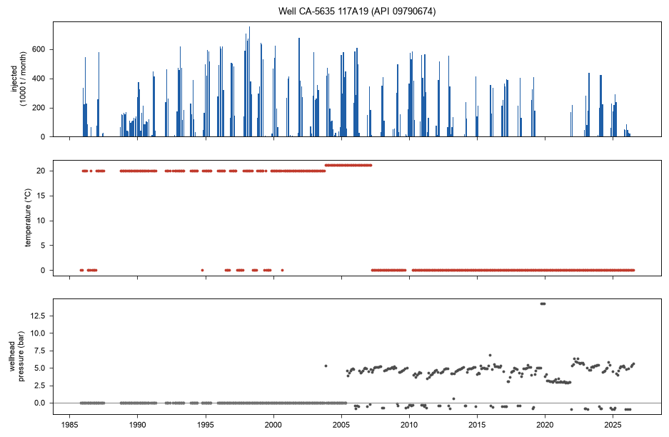

Three things are visible in one well.

- **Injection switches on and off** from month to month, because the operator moves water between wells. A well's monthly series is therefore far from smooth.
- **The temperature is not a measurement here.** It reads exactly 20 °C, then 21 °C, then 0 for two decades: a default value, then a blank.
- **The pressure was not reported before 2005**, and reads about 5 bar while the well injects.

This well is unusual in one way. Across all wells, in the months when water was injected, the wellhead pressure is negative in about half the reports, typically −0.8 bar: a partial vacuum. The steam reservoir is below hydrostatic pressure, so the water falls in under its own weight and no pumping pressure is needed at the surface. A wellhead pressure therefore says little about the pressure at depth, where the earthquakes happen.

### 2.3 · Which columns can we trust?

Reports are typed in by operators over five decades. Before using any column, look at its range. Zero is used both for "nothing injected" and for "not measured", so the table below summarises only the months in which water was injected.

```python
on = inj[inj.injected_t > 0]
cols = ["days", "injected_t", "rate_t_per_hr", "temperature_c", "pressure_bar", "tds_1000ppm",
        "density_1000kg_m3"]
summary = on[cols].describe(percentiles=[0.01, 0.5, 0.99]).T
summary["zeros"] = (on[cols] == 0).sum()
summary.round(2)
```

|  | count | mean | std | min | 1% | 50% | 99% | max | zeros |
| --- | --- | --- | --- | --- | --- | --- | --- | --- | --- |
| days | 17796.0 | 26.49 | 7.99 | 0.0 | 1.00 | 30.0 | 31.00 | 3.100000e+01 | 105 |
| injected_t | 17796.0 | 71558.68 | 63398.42 | 2.0 | 301.85 | 57400.5 | 304237.10 | 9.054040e+05 | 0 |
| rate_t_per_hr | 17792.0 | 193.59 | 2143.21 | -165.5 | 0.00 | 79.5 | 877.75 | 1.162599e+05 | 1858 |
| temperature_c | 17518.0 | 9.25 | 19.65 | 0.0 | 0.00 | 0.0 | 54.00 | 4.757000e+02 | 11265 |
| pressure_bar | 17791.0 | 0.17 | 2.82 | -15.0 | -1.20 | -0.7 | 11.91 | 5.110000e+01 | 5773 |
| tds_1000ppm | 17513.0 | 61805.67 | 1423424.79 | 0.0 | 0.00 | 0.0 | 11.70 | 1.025861e+08 | 11928 |
| density_1000kg_m3 | 17513.0 | 0.37 | 0.48 | 0.0 | 0.00 | 0.0 | 1.00 | 3.130000e+00 | 11076 |

`injected_t` and `days` behave. The other columns contain values that cannot be real: a density of 3 (three times water), dissolved solids of millions of parts per thousand, and temperatures of hundreds of degrees for water that was condensed at the surface. Many zeros are missing measurements: after 2010 almost no report gives a temperature. The mass injected is the column the rest of this notebook uses.

A consistency check on it: injected mass should equal the rate times the hours of injection.

```python
ok = on[(on.days > 0) & (on.rate_t_per_hr > 0)]
ratio = ok.injected_t / (ok.rate_t_per_hr * 24 * ok.days)
print(f"injected / (rate x hours), {len(ok):,} well-months:")
print("   percentiles 5/25/50/75/95:", np.round(ratio.quantile([.05, .25, .5, .75, .95]).values, 2))
```

```
injected / (rate x hours), 15,911 well-months:
   percentiles 5/25/50/75/95: [0.51 0.9  1.   1.09 1.93]
```

## § 3 · Per-well reports against the field totals

The project notebook's injection series is CalGEM's field total, `production()`. If the per-well reports were complete, their sum would reproduce it. Comparing the two tells us how much of the injected water the per-well files account for.

```python
prod = production()                                        # million tonnes per month
wsum = inj.groupby("date").injected_t.sum() / 1e6
both = pd.DataFrame({"field total": prod.injection, "sum of wells": wsum}).dropna()
both = both[both["field total"] > 0]
yearly = both.groupby(both.index.year).sum()
yearly["fraction"] = yearly["sum of wells"] / yearly["field total"]
n_active = inj[inj.injected_t > 0].groupby("year").api.nunique()

fig, axs = plt.subplots(3, 1, figsize=(10, 7.5), sharex=True)
axs[0].plot(yearly.index, yearly["field total"], "-o", ms=3, color="k", label="CalGEM field total")
axs[0].plot(yearly.index, yearly["sum of wells"], "-o", ms=3, color="#1f5fa8",
            label="sum of the per-well reports")
axs[0].set_ylabel("injection\n(million t / yr)")
axs[0].legend(fontsize=8)
axs[1].plot(yearly.index, yearly.fraction, "-o", ms=3, color="#1f5fa8")
axs[1].axhline(1, color="0.6", lw=0.8)
axs[1].set_ylim(0, 1.2)
axs[1].set_ylabel("fraction\naccounted for")
axs[2].bar(n_active.index, n_active.values, color="0.5")
axs[2].set_ylabel("wells injecting\n(per year)")
for ax in axs:
    for y in (1997.9, 2003.9):
        ax.axvline(y, color="#c0392b", lw=0.8, ls="--")
axs[0].set_title("Per-well injection reports against the field total")
plt.show()
print(yearly.loc[[1985, 1995, 2005, 2015, 2025]].round(2).to_string())
```

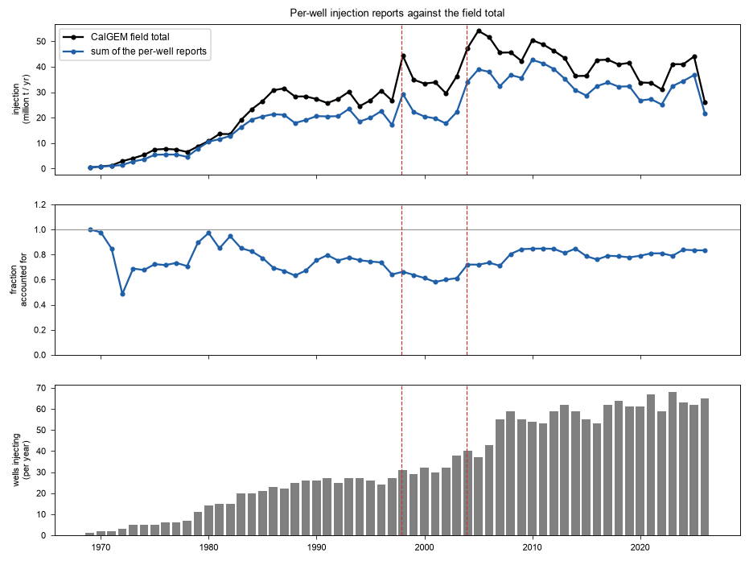

```
      field total  sum of wells  fraction
1985        26.52         20.50      0.77
1995        26.83         19.98      0.74
2005        54.11         38.94      0.72
2015        36.43         28.71      0.79
2025        44.02         36.74      0.83
```

Two step increases stand out, marked by the dashed lines: around 1998 and around 2004. They are when piped wastewater began to arrive from outside the field, first from Lake County (the Southeast Geysers Effluent Pipeline) and then from Santa Rosa (the Santa Rosa Geysers Recharge Project). The number of injecting wells grows at the same times.

**Consequence for analysis.** A per-well sum is the right tool to ask *where* water goes. For the field's *total* forcing, the CalGEM field total remains the better record.

## § 4 · Where the water goes

§ 3 found two step increases in injection, around 1998 and 2004. Did the new water go to the same wells, or to new parts of the field? We split the record into three periods at those steps and map, for each well, its mean injection per year in that period. Behind the wells are that period's earthquakes of M ≥ 1.5.

M ≥ 1.5 is used only to draw the background; it is close to complete in all three periods, though not exactly. Compare the *pattern* of seismicity between panels, not the number of dots.

```python
PERIODS = [(1980, 1997), (1998, 2003), (2004, 2025)]
loc = wells.set_index("api")[["longitude", "latitude"]]

fig, axs = plt.subplots(1, 3, figsize=(15, 5.2))
for ax, (y0, y1) in zip(axs, PERIODS):
    rate = (inj[inj.year.between(y0, y1)].groupby("api").injected_t.sum()
            / (y1 - y0 + 1) / 1e6)                                   # million t per year
    rate = rate[rate > 0]
    p = loc.loc[rate.index]
    e = cat[cat.year.between(y0, y1) & (cat.mag >= 1.5)
            & cat.longitude.between(*ZOOM[:2]) & cat.latitude.between(*ZOOM[2:])]
    basemap(ax, L, ZOOM)
    ax.scatter(e.longitude, e.latitude, s=1.5, color="#e07b4f", alpha=0.3, lw=0, zorder=3)
    ax.scatter(p.longitude, p.latitude, s=rate * 150, color="#1f5fa8", alpha=0.75,
               edgecolor="white", lw=0.5, zorder=5)
    frame(ax, ZOOM, xtick=0.1, ytick=0.05, scale_km=5, scale_loc=(.6, .06))
    ax.set_title(f"{y0}–{y1}: {len(rate)} wells, {rate.sum():.0f} Mt/yr; "
                 f"{len(e):,} events", fontsize=9)
for r in (0.2, 0.5, 1.0):                                           # legend for bubble size
    axs[0].scatter([], [], s=r * 150, color="#1f5fa8", alpha=0.75, label=f"{r} Mt/yr")
axs[0].legend(loc="lower left", fontsize=7, labelspacing=1.2, framealpha=0.9)
plt.show()
```

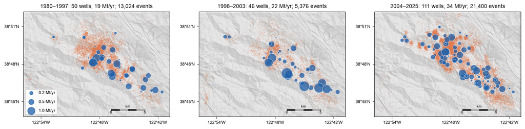

The three panels differ in where the large injectors are.

- **1980–1997.** About 50 wells, spread along the central and south-eastern field.
- **1998–2003.** The largest injectors are in the south-east, the part of the field the first pipeline served.
- **2004–2025.** More than twice as many wells, and the heaviest injection moves to the central and northern field, where the densest seismicity of that period also lies.

This is a picture, not a test. Production also moved over these years, and the network that locates the earthquakes changed. § 5 asks the question in time, at one place.

## § 5 · Injection and nearby seismicity

### 5.1 · The comparison

For one well, we compare two monthly series:

- the water it injected;
- the number of earthquakes with M ≥ 1.2 whose epicentre lies within **1.5 km of its wellhead**.

The radius is a compromise. It must be large enough to reach the bottom of a deviated well (§ 1.3), and small enough that most of the earthquakes are near this well rather than its neighbours. We use 2006–2025, when the catalogue is complete well below M 1.2 and most wells report.

```python
T0, T1, R_KM, M_MIN = "2006-01-01", "2025-12-01", 1.5, 1.2
months = pd.date_range(T0, T1, freq="MS")
eq = cat[(cat.mag >= M_MIN) & (cat.time >= pd.Timestamp(T0, tz="UTC"))
         & (cat.time < pd.Timestamp(T1, tz="UTC") + pd.offsets.MonthBegin(1))].copy()
eq["month"] = eq.time.dt.tz_localize(None).dt.to_period("M").dt.to_timestamp()


def series(api):
    """Monthly injection (thousand t) and nearby earthquake count for one well."""
    w = wells.set_index("api").loc[api]
    dx = (eq.longitude - w.longitude) * KM_LON
    dy = (eq.latitude - w.latitude) * KM_LAT
    near = eq[np.hypot(dx, dy) <= R_KM]
    n = near.groupby("month").size().reindex(months, fill_value=0)
    q = inj[inj.api == api].set_index("date").injected_t.reindex(months, fill_value=0) / 1e3
    return q, n


top = inj.groupby("api").injected_t.sum().idxmax()             # the well of § 2.2
q, n = series(top)
fig, ax = plt.subplots(figsize=(10, 3.6))
ax.bar(q.index, q, width=25, color="#1f5fa8", label="injected (1000 t / month)")
ax.set_ylabel("injected (1000 t / month)", color="#1f5fa8")
ax2 = ax.twinx()
ax2.plot(n.index, n, color="#e07b4f", lw=1.2, label=f"earthquakes within {R_KM} km")
ax2.set_ylabel(f"M ≥ {M_MIN} within {R_KM} km\n(per month)", color="#e07b4f")
ax.set_title(f"Well {wells.set_index('api').loc[top, 'name']}: injection and nearby seismicity")
plt.show()
print(f"correlation of the two monthly series: r = {np.corrcoef(q, n)[0, 1]:.2f}")
```

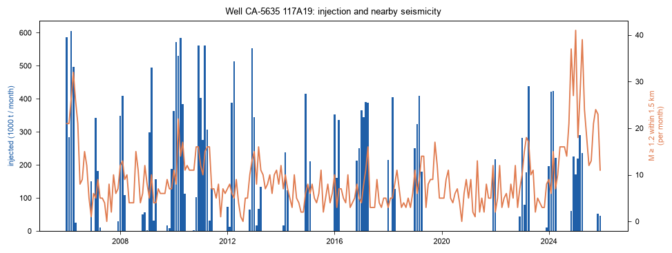

```
correlation of the two monthly series: r = 0.34
```

When this well injects heavily for several months, the nearby earthquake count tends to rise; when it stops, the count falls. The match is far from perfect. Neighbouring wells inject too, and their water reaches the same rock.

### 5.2 · Is one well's correlation meaningful?

One correlation coefficient means little until we know what value chance would give. Both series have slow trends and seasonal cycles, and two series that each vary slowly can correlate by accident.

A simple null hypothesis: **shift the injection series in time** by a random number of months (wrapping around the end), and recompute the correlation. A shift keeps each series' own character, its trends and its on-off pattern, but destroys any alignment between them. If the true correlation is larger than nearly all shifted ones, the alignment is unlikely to be chance.

We do this for every well that injected in at least 24 months of the window.

```python
rng = np.random.default_rng(207)
active = inj[(inj.date >= T0) & (inj.injected_t > 0)].groupby("api").size()
rows = []
for api in active[active >= 24].index:
    q, n = series(api)
    if n.sum() < 20:                                           # too few events to correlate
        continue
    r = np.corrcoef(q, n)[0, 1]
    shifts = rng.integers(12, len(months) - 12, 500)           # at least a year away
    null = np.array([np.corrcoef(np.roll(q.values, s), n)[0, 1] for s in shifts])
    rows.append(dict(api=api, r=r, p=(null >= r).mean(), events=int(n.sum())))
res = pd.DataFrame(rows)
print(f"{len(res)} wells tested; median r = {res.r.median():.2f}")
print(f"wells with p < 0.05: {(res.p < 0.05).sum()} (chance alone would give about {0.05 * len(res):.0f})")

fig, axs = plt.subplots(1, 2, figsize=(10, 3.5))
axs[0].hist(res.r, bins=20, color="#1f5fa8")
axs[0].axvline(0, color="k", lw=0.8)
axs[0].set(xlabel="correlation r, injection vs nearby events", ylabel="wells")
axs[1].hist(res.p, bins=20, range=(0, 1), color="0.5")
axs[1].set(xlabel="p (fraction of shifted series with r at least as large)", ylabel="wells")
fig.suptitle("All injection wells, 2006–2025")
fig.tight_layout()
plt.show()
```

```
87 wells tested; median r = 0.19
wells with p < 0.05: 29 (chance alone would give about 4)
```

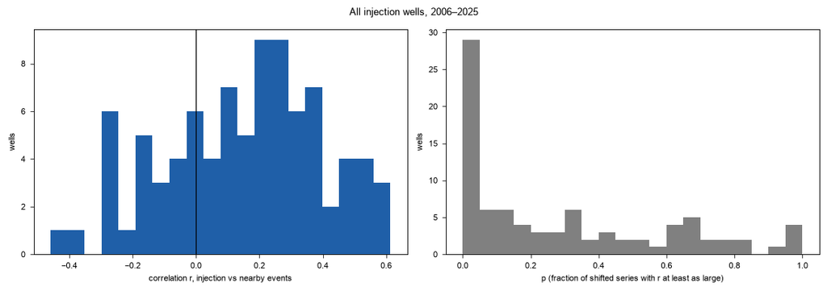

If injection had no effect on nearby seismicity, the correlations would centre on zero and the p-values would be spread evenly between 0 and 1. Compare that expectation with the two histograms. Neither holds. Most correlations are positive (median about 0.2), and about a third of the wells have p < 0.05, where chance alone would give about one in twenty. At many wells, months of heavy injection are months of more nearby earthquakes, more often than chance allows.

What this test cannot tell us:

- **Which well.** Wells inject at the same time as their neighbours, so a correlation at one well may belong to another. The tests are not independent.
- **Cause.** The operator may inject more when more steam is produced, and production may also affect seismicity.
- **Depth.** We used wellhead positions and ignored depth (§ 1.3).

These are the questions a final project could take further.

## § 6 · Takeaways

**The seismology**

- Wells and earthquakes share one NW–SE band, which by itself says nothing about cause.
- Injection grew in two steps, around 1998 and 2004, and after 2004 moved toward the central and northern field.
- At about a third of the wells, monthly injection correlates with nearby seismicity more than a time-shifted null allows, but the test cannot separate neighbouring wells or production.

**Directions for a final project**

- Group wells into clusters and repeat § 5 per cluster, so neighbouring wells stop competing.
- Add a time lag: does seismicity follow injection by weeks or months?
- Use relocated earthquakes and their depths, and ask whether events near a well deepen as injection continues.
- Compare the *b*-value of earthquakes near heavy injectors with that of the rest of the field.